[figure not shown]

# Web Scraping for Indeed.com and Predicting Salaries

In this project, we will practice two major skills: collecting data by scraping a website and then building a binary predictor with Logistic Regression.

We are going to collect salary information on data science jobs in a variety of markets. Then using the location, title and summary of the job we will attempt to predict the salary of the job. For job posting sites, this would be extraordinarily useful. While most listings DO NOT come with salary information (as you will see in this exercise), being able to extrapolate or predict the expected salaries from other listings can help guide negotiations.

Normally, we could use regression for this task; however, we will convert this problem into classification and use Logistic Regression or any other suitable classifier.

- Question: Why would we want this to be a classification problem?
- Answer: While more precision may be better, there is a fair amount of natural variance in job salaries - predicting a range may be useful.

Therefore, the first part of the assignment will be focused on scraping Indeed.com. In the second, we'll focus on using listings with salary information to build a model and predict additional salaries.

## QUESTION 1: Scraping job listings from Indeed.com

We will be scraping job listings from Indeed.com using BeautifulSoup. Luckily, Indeed.com is a simple text page where we can easily find relevant entries.

First, look at the source of an Indeed.com page: (http://www.indeed.com/jobs?q=data+scientist+%2420%2C000&l=New+York&start=10").

Notice, each job listing is underneath a `div` tag with a class name of `result`. We can use BeautifulSoup to extract those.

### Setup a request

**(using `requests`) to the URL below. Use BeautifulSoup to parse the page and extract all results (HINT: Look for div tags with class name result)**

The URL here has many query parameters:

- `q` for the job search
- This is followed by "+20,000" to return results with salaries (or expected salaries >$20,000)
- `l` for a location
- `start` for what result number to start on

```python
URL = "http://www.indeed.com/jobs?q=data+scientist+%2420%2C000&l=New+York&start=10"
```

```python
jobs=[]
r = requests.get(URL)
```

```python
soup = BeautifulSoup(r.text, 'html.parser')
```

```python
my_soup=soup.find_all('div', class_='result')
```

```python
for i in my_soup:
    jobs.append(my_soup)

print("Total number of jobs scraped: " + str(len(jobs)) +"\n")
```

```
Total number of jobs scraped: 10
```

```python
# jobs[0]
```

Let's look at one result more closely. A single `result` looks like

```
<div class=" row result" data-jk="2480d203f7e97210" data-tn-component="organicJob" id="p_2480d203f7e97210" itemscope="" itemtype="http://schema.org/JobPosting">
<h2 class="jobtitle" id="jl_2480d203f7e97210">
<a class="turnstileLink" data-tn-element="jobTitle" onmousedown="return rclk(this,jobmap[0],1);" rel="nofollow" target="_blank" title="AVP/Quantitative Analyst">AVP/Quantitative Analyst</a>
</h2>
<span class="company" itemprop="hiringOrganization" itemtype="http://schema.org/Organization">
<span itemprop="name">
<a href="/cmp/Alliancebernstein?from=SERP&campaignid=serp-linkcompanyname&fromjk=2480d203f7e97210&jcid=b374f2a780e04789" target="_blank">
    AllianceBernstein</a></span>
</span>
<tr>
<td class="snip">
<nobr>$117,500 - $127,500 a year</nobr>
<div>
<span class="summary" itemprop="description">
C onduct quantitative and statistical research as well as portfolio management for various investment portfolios. Collaborate with Quantitative Analysts and</span>
</div>
</div>
</td>
</tr>
</table>
</div>
```

While this has some more verbose elements removed, we can see that there is some structure to the above:

- The salary is available in a `nobr` element inside of a `td` element with `class='snip'`.
- The title of a job is in a link with class set to `jobtitle` and a `data-tn-element='jobTitle'`.
- The location is set in a `span` with `class='location'`.
- The company is set in a `span` with `class='company'`.

### Write 4 functions to extract each item: location, company, job, and salary.

Example:

```
def extract_location_from_result(result):
    return result.find ...
```

- **Make sure these functions are robust and can handle cases where the data/field may not be available.**
  - Remember to check if a field is empty or `None` for attempting to call methods on it.
  - Remember to use `try/except` if you anticipate errors.
- **Test** the functions on the results above and simple examples.

```python
def extract_location_from_result(soup):
    locations = []
    for job in soup.find_all('div', attrs={'class': 'result'}):
        location = job.find('span', attrs={'class': 'location'})
        if location == None:
            locations.append('None')
        else:
            locations.append(location.text.replace('\n','').strip())
    return locations
```

```python
def extract_company_from_result(soup):
    companies = []
    for job in soup.find_all('div', attrs={'class': 'result'}):
        company = job.find('span', attrs={'class': 'company'})
        if company == None:
            companies.append('None')
        else:
            companies.append(company.text.replace('\n','').strip())
    return companies
```

```python
def extract_job_from_result(soup):
    jobs = []
    for job in soup.find_all('div', attrs={'class': 'result'}):
        job_title = job.find('a', attrs={'class': 'turnstileLink'})
        if job_title == None:
            jobs.append('None')
        else:
            jobs.append(job_title.text.replace('\n','').strip())
    return jobs
```

```python
def extract_salary_from_result(soup):
    salaries = []
    for job in soup.find_all('div', attrs={'class': 'result'}):
        salary = job.find('span', attrs={'class': 'no-wrap'})
        if salary == None:
            salaries.append('None')
        else:
            salaries.append(salary.text.replace('\n','').strip())
    return salaries
```

```python
def extract_summary_from_result(soup):
    summaries = []
    for job in soup.find_all('div', attrs={'class': 'result'}):
        summary = job.find('span', attrs={'class': 'summary'})
        if summary == None:
            summaries.append('None')
        else:
            summaries.append(summary.text.replace('\n','').strip())
    return summaries
```

Now, to scale up our scraping, we need to accumulate more results. We can do this by examining the URL above.

- "http://www.indeed.com/jobs?q=data+scientist+%2420%2C000&l=New+York&start=10"

There are two query parameters here we can alter to collect more results, the `l=New+York` and the `start=10`. The first controls the location of the results (so we can try a different city). The second controls where in the results to start and gives 10 results (thus, we can keep incrementing by 10 to go further in the list).

### Complete the following code to collect results from multiple cities and starting points.

- Enter your city below to add it to the search.
- Remember to convert your salary to U.S. Dollars to match the other cities if the currency is different.

```python
url_template = "https://www.indeed.co.uk/jobs?q=data+science&l={}&start={}"
max_results_per_city = 1000

# results = {'Location': [],
#            'Company': [],
#            'Job': [],
#            'Specific_location': [],
#            'Salary': [],
#            'Summary': []}
results=[]
cities=[]

for city in ['London', 'Birmingham', 'Newcastle', 'Cambridge', 'Manchester',
                      'Bristol', 'Liverpool', 'Leeds', 'York', 'Glasgow', 'Sheffield',
                      'Oxford', 'Cardiff', 'Belfast', 'Edinburgh']:
    print('Completed: ', city)

    #Printing out city just to let us know which city we are scraping


    for start in range(0, max_results_per_city, 10):

        r = requests.get(url_template.format(city, start))
        soup = BeautifulSoup(r.text, 'html.parser')
        page_results = soup.findAll('div', class_='result')

        for page_result in page_results:
            cities.append(city)
            results.extend(page_results)



#         location = [city.replace(
#             '+', ' ') for job in soup.find_all('div', attrs={'class': 'result'})]
#         company = extract_company_from_result(soup)
#         job = extract_job_from_result(soup)
#         specific_location = extract_location_from_result(soup)
#         salary = extract_salary_from_result(soup)
#         summary = extract_summary_from_result(soup)

#         results['Location'].extend(location)
#         results['Company'].extend(company)
#         results['Job'].extend(job)
#         results['Specific_location'].extend(specific_location)
#         results['Salary'].extend(salary)
#         results['Summary'].extend(summary)
```

```
Completed:  London
Completed:  Birmingham
Completed:  Newcastle
Completed:  Cambridge
Completed:  Manchester
Completed:  Bristol
Completed:  Liverpool
Completed:  Leeds
Completed:  York
Completed:  Glasgow
Completed:  Sheffield
Completed:  Oxford
Completed:  Cardiff
Completed:  Belfast
Completed:  Edinburgh
```

```python
len(results)
```

```
345627
```

```python
url_template = "https://www.indeed.co.uk/jobs?q=data+science&l={}&start={}"
max_results_per_city = 1000

results = {'Location': [],
           'Company': [],
           'Job': [],
           'Salary': [],
           'Summary': []}

for city in ['London', 'Edinburgh', 'Newcastle', 'Cambridge', 'Manchester', 'Birmingham','Hull'
                      'Bristol', 'Liverpool', 'Leeds', 'York', 'Glasgow', 'Sheffield',
                      'Oxford', 'Cardiff', 'Belfast']:

    #Printing out city just to let us know which city we are scraping
    print('Completed: ', city)

    for start in range(0, max_results_per_city, 10):

        r = requests.get(url_template.format(city, start))
        soup = BeautifulSoup(r.text, 'html.parser')

        location = [city.replace(
            '+', ' ') for job in soup.find_all('div', attrs={'class': 'result'})]
        company = extract_company_from_result(soup)
        job = extract_job_from_result(soup)
        specific_location = extract_location_from_result(soup)
        salary = extract_salary_from_result(soup)
        summary = extract_summary_from_result(soup)

        results['Location'].extend(location)
        results['Company'].extend(company)
        results['Job'].extend(job)
        results['Salary'].extend(salary)
        results['Summary'].extend(summary)
```

```
Completed:  London
Completed:  Edinburgh
Completed:  Newcastle
Completed:  Cambridge
Completed:  Manchester
Completed:  Birmingham
Completed:  HullBristol
Completed:  Liverpool
Completed:  Leeds
Completed:  York
Completed:  Glasgow
Completed:  Sheffield
Completed:  Oxford
Completed:  Cardiff
Completed:  Belfast
```

```python
df = pd.DataFrame(results)
```

```python
# Export data so this i dont have to run this again
df.to_csv('df_scrape.csv')
```

```python
# reload
df = pd.read_csv('df_scrape.csv')
```

```python
df.head()
```

[output not shown]

```python
# remove first column
df = df.iloc[:,1:]
df.head()
```

[output not shown]

```python
job_data.describe()
```

[output not shown]

Lastly, we need to clean up salary data.

1. Only a small number of the scraped results have salary information - only these will be used for modeling.
2. Some of the salaries are not yearly but hourly or weekly, these will not be useful to us for now.
3. Some of the entries may be duplicated.
4. The salaries are given as text and usually with ranges.

#### Find the entries with annual salary entries, by filtering the entries without salaries or salaries that are not yearly (filter those that refer to hour or week). Also, remove duplicate entries.

```python
# Check nulls
df.isnull().sum()
```

```
Company              0
Job                  0
Location             0
Salary               0
Specific_location    0
Summary              0
dtype: int64
```

```python
# remove the 'None" salaries
sal = df['Salary']!='None'
```

```python
df = df.drop_duplicates(
    subset=['Company', 'Job', 'Salary', 'Summary']).loc[sal,:].reset_index(drop=True)
```

```python
df.head()
```

|  | Company | Job | Location | Salary | Specific_location | Summary |
| --- | --- | --- | --- | --- | --- | --- |
| 0 | Boba Group Limited | Trading Support / Data Analyst | London | £36,000 - £46,000 a year | None | Exceptional data manipulation skills which can... |
| 1 | SparkBeyond | Data Scientist | London | £55,000 - £100,000 a year | None | 4+ years of relevant experience in Data Scienc... |
| 2 | Anna Freud National Centre for Children and Fa... | Research Assistant - Data | London | £23,000 - £30,000 a year | London N1 | Research Assistant - Data*. This is an excelle... |
| 3 | University of Westminster | Research Fellow (Health Data Science) | London | £40,173 - £44,615 a year | London | You will have also a publication record in rel... |
| 4 | Jamy Interactive | Data Scientist / 75% Travel Job | London | £50,000 - £65,000 a year | London | To identify opportunities for how advanced tec... |

```python
for timeframe in ['day','hour','week','month']:
    df = df.loc[~df['Salary'].str.contains(timeframe)]
```

#### Write a function that takes a salary string and converts it to a number, averaging a salary range if necessary.

```python
def get_sal(string):
    string = string.replace('£','').replace(',','')
    pieces = string.split()
    numbers = [float(piece) for piece in pieces if piece.isdigit()]
    sal = np.mean(numbers)
    return sal
```

```python
df['clean_salary'] = df['Salary'].map(get_sal)
```

```python
df.head()
```

|  | Company | Job | Location | Salary | Specific_location | Summary | clean_salary |
| --- | --- | --- | --- | --- | --- | --- | --- |
| 0 | Boba Group Limited | Trading Support / Data Analyst | London | £36,000 - £46,000 a year | None | Exceptional data manipulation skills which can... | 41000.0 |
| 1 | SparkBeyond | Data Scientist | London | £55,000 - £100,000 a year | None | 4+ years of relevant experience in Data Scienc... | 77500.0 |
| 2 | Anna Freud National Centre for Children and Fa... | Research Assistant - Data | London | £23,000 - £30,000 a year | London N1 | Research Assistant - Data*. This is an excelle... | 26500.0 |
| 3 | University of Westminster | Research Fellow (Health Data Science) | London | £40,173 - £44,615 a year | London | You will have also a publication record in rel... | 42394.0 |
| 4 | Jamy Interactive | Data Scientist / 75% Travel Job | London | £50,000 - £65,000 a year | London | To identify opportunities for how advanced tec... | 57500.0 |

### Check data

```python
df.info()
```

```
<class 'pandas.core.frame.DataFrame'>
Int64Index: 1230 entries, 0 to 1319
Data columns (total 7 columns):
Company              1230 non-null object
Job                  1230 non-null object
Location             1230 non-null object
Salary               1230 non-null object
Specific_location    1230 non-null object
Summary              1230 non-null object
clean_salary         1230 non-null float64
dtypes: float64(1), object(6)
memory usage: 76.9+ KB
```

### Save your results as a CSV

```python
 df.to_csv('job_data_final.csv')
```

## QUESTION 2: Factors that distinguish job category

Using the job postings you scraped for part 1 (or potentially new job postings from a second round of scraping), identify features in the data related to job postings that can distinguish job titles from each other. There are a variety of interesting ways you can frame the target variable, for example:

- What components of a job posting distinguish data scientists from other data jobs?
- What features are important for distinguishing junior vs. senior positions?
- Do the requirements for titles vary significantly with industry (e.g. healthcare vs. government)?

You may end up making multiple classification models to tackle different questions. Be sure to clearly explain your hypotheses and framing, any feature engineering, and what your target variables are. The type of classification model you choose is up to you. Be sure to interpret your results and evaluate your models' performance.

### Load in the the data of scraped salaries

```python
df = pd.read_csv('job_data_final.csv')
```

```python
df = df.iloc[:,1:]
df.head()
```

|  | Company | Job | Location | Salary | Specific_location | Summary | clean_salary |
| --- | --- | --- | --- | --- | --- | --- | --- |
| 0 | Boba Group Limited | Trading Support / Data Analyst | London | £36,000 - £46,000 a year | None | Exceptional data manipulation skills which can... | 41000.0 |
| 1 | SparkBeyond | Data Scientist | London | £55,000 - £100,000 a year | None | 4+ years of relevant experience in Data Scienc... | 77500.0 |
| 2 | Anna Freud National Centre for Children and Fa... | Research Assistant - Data | London | £23,000 - £30,000 a year | London N1 | Research Assistant - Data*. This is an excelle... | 26500.0 |
| 3 | University of Westminster | Research Fellow (Health Data Science) | London | £40,173 - £44,615 a year | London | You will have also a publication record in rel... | 42394.0 |
| 4 | Jamy Interactive | Data Scientist / 75% Travel Job | London | £50,000 - £65,000 a year | London | To identify opportunities for how advanced tec... | 57500.0 |

**We want to predict a binary variable - whether the salary was low or high. Compute the median salary and create a new binary variable that is true when the salary is high (above the median).**

We could also perform Linear Regression (or any regression) to predict the salary value here. Instead, we are going to convert this into a *binary* classification problem, by predicting two classes, HIGH vs LOW salary.

While performing regression may be better, performing classification may help remove some of the noise of the extreme salaries. We don't have to choose the `median` as the splitting point - we could also split on the 75th percentile or any other reasonable breaking point.

In fact, the ideal scenario may be to predict many levels of salaries.

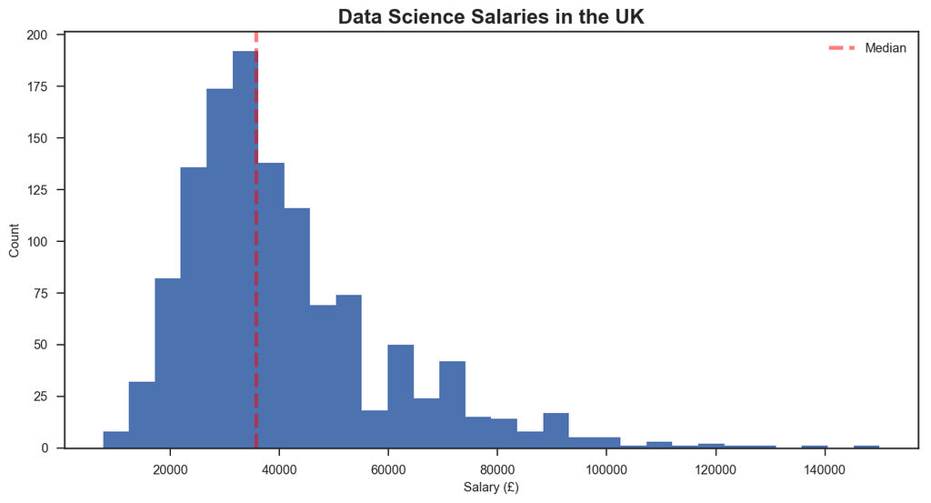

```python
fig, ax = plt.subplots(figsize=(12,6))
ax.hist(df['clean_salary'], bins=30)
ax.axvline(np.median(df['clean_salary']), c='red', alpha=0.5, ls='dashed', lw=3)
ax.legend(['Median'], fontsize=10)
ax.set_xlabel('Salary (£)', fontsize=10)
ax.set_ylabel('Count', fontsize=10)
ax.set_title('Data Science Salaries in the UK', fontsize=16, fontweight='bold')
plt.show()
```

```python
median_salary=np.median(df.clean_salary)
median_salary
```

```
35806.5
```

```python
df['high_sal']=[1 if i > median_salary else 0 for i in df.clean_salary]
```

```python
df.high_sal.value_counts()
```

```
0    617
1    613
Name: high_sal, dtype: int64
```

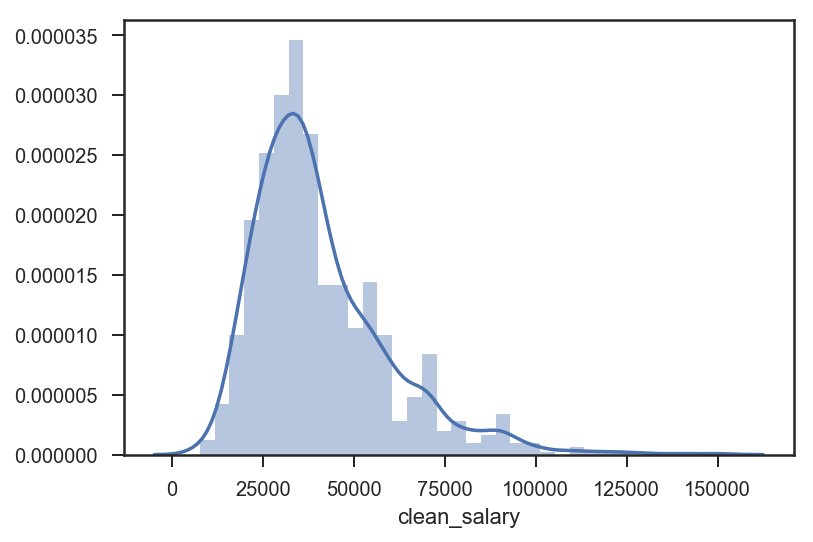

```python
sns.set(style="ticks", color_codes=False)
sns.distplot(df.clean_salary, color='b')
plt.show();
```

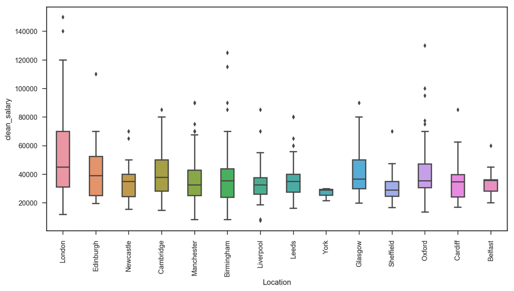

```python
fig, ax = plt.subplots(figsize=(12,6))
sns.boxplot(df['Location'], df['clean_salary'], width=0.4)
plt.xticks(rotation=90)
```